# Importing and Processing Data

Rafael Maia, Thomas White, Hugo Gruson, Pierre-Paul Bitton, Chad Eliason

2018-12-21

# Organizing Spectral Data

Let’s begin by loading the package.

```r
# Load the package, and set a global random-number seed for the reproducible generation of fake data later on.
library(pavo)
set.seed(1612217)
```

## Spectral Dataset Description

The raw spectral data used in this example are available from the package reporitory on [github](https://github.com/rmaia/pavo), located [here](https://github.com/rmaia/pavo/blob/master/data_external/vignette). You can download and extract it to follow the vignette exactly. Alternatively, the data are included as an RData file as part of the package installation, and so can be loaded directly (see below).

In addition, `pavo` includes three datasets that can be called with the `data` function. `data(teal)`, `data(sicalis)`, and `data(flowers)` will all be used in this vignette. See the help files for each dataset for more informationl; via `?teal`, `?sicalis`, and `?flowers`.

## Importing

The first thing we need to do is import spectral data into R using the function `getspec()`. Since the example spectra were obtained using Avantes software, we will need to specify that the files have the `.ttt` extension. Further, the data is organized in subdirectories for each species. `getspec()` will search through subdirectories recursively, and may include the names of the subdirectories in the spectra name if desired. `getspec()` also uses parallel processing when the argument `cores` is set to a number greater than `1` (currently available only on Linux and Mac). A final issue with the data is that it was collected using a computer with international numbering input, which means it uses commas instead of periods as a decimal separator. We can specify that in the function call.

If, for example, the raw spectral files were downloaded and placed in a directory called `/pavo/data_external/vignette`, you might execute the following command and see this output:

```r
specs <- getspec("~/pavo/data_external/vignette", ext = "ttt", decimal = ",", subdir = TRUE, subdir.names = FALSE)
# 213  files found; importing spectra
# |================================================================================| 100%, ETA 00:00
```

For convenience, however, we’ve included the spectra as an RData file in the package installation, and so will simply load it directly.

```r
specs <- readRDS(system.file("extdata/specsdata.rda", package = "pavo"))
```

And we can inspect the resulting object:

```r
specs[1:10, 1:4]
```

```
##     wl cardinal.0001 cardinal.0002 cardinal.0003
## 1  300        5.7453        8.0612        8.0723
## 2  301        6.0181        8.3926        8.8669
## 3  302        5.9820        8.8280        9.0680
## 4  303        6.2916        8.7621        8.7877
## 5  304        6.6277        8.6819        9.3450
## 6  305        6.3347        9.6016        9.4834
## 7  306        6.3189        9.5712        9.3533
## 8  307        6.7951        9.4650        9.9492
## 9  308        7.0758        9.4677        9.8587
## 10 309        7.2126       10.6172       10.5396
```

```r
dim(specs) # the data set has 213 spectra, from 300 to 700 nm, plus a 'wl' column
```

```
## [1] 401 214
```

When `pavo` imports spectra, it creates an object of class `rspec`, which inherits attributes from the `data.frame` class:

```r
is.rspec(specs)
```

```
## [1] TRUE
```

If you already have multiple spectra in a single data frame that you’d like to use with `pavo` functions, you can use the command `as.rspec()` to convert it to an rspec object. The function will attempt to identify the wavelength variable or you can specify the column containing wavelengths with the `whichwl` argument. The default way that `as.rspec()` handles reflectance data is to interpolate the data in 1-nm bins, as is commonly done for spectral analyses. However, this can be turned off by using: `interp = FALSE`. As an example, we will create some fake reflectance data, name the column containing wavelengths (in 0.5-nm bins) *wavelength* rather than *wl* (required for `pavo` functions to work) and also put the column containing wavelengths third rather than first.

```r
# Create some fake reflectance data with wavelength column arbitrarily titled
# and not first in the data frame:
fakedat <- data.frame(
  refl1 = rnorm(n = 801),
  refl2 = rnorm(n = 801),
  wavelength = seq(300, 700, by = .5)
)
head(fakedat)
```

```
##          refl1      refl2 wavelength
## 1 -0.032893386  0.5059612      300.0
## 2 -0.478552738 -1.1526035      300.5
## 3 -0.190687886 -1.0708952      301.0
## 4 -0.008977959 -1.9871907      301.5
## 5 -0.443133039 -0.3910143      302.0
## 6  0.032110206 -0.5403221      302.5
```

```r
is.rspec(fakedat)
```

```
## [1] FALSE
```

```r
fakedat.new <- as.rspec(fakedat)
```

```
## wavelengths found in column 3
```

```
##
## The spectral data contain 858 negative value(s), which may produce unexpected results if used in models. Consider using procspec() to correct them.
```

```r
is.rspec(fakedat.new)
```

```
## [1] TRUE
```

```r
head(fakedat.new)
```

```
##    wl       refl1       refl2
## 1 300 -0.03289339  0.50596119
## 2 301 -0.19068789 -1.07089518
## 3 302 -0.44313304 -0.39101435
## 4 303 -0.52064707  0.84403232
## 5 304  1.42813472  0.07150436
## 6 305 -0.19044804 -0.84504226
```

```r
head(as.rspec(fakedat, whichwl = 'wavelength'))
```

```
##
## The spectral data contain 858 negative value(s), which may produce unexpected results if used in models. Consider using procspec() to correct them.
```

```
##    wl       refl1       refl2
## 1 300 -0.03289339  0.50596119
## 2 301 -0.19068789 -1.07089518
## 3 302 -0.44313304 -0.39101435
## 4 303 -0.52064707  0.84403232
## 5 304  1.42813472  0.07150436
## 6 305 -0.19044804 -0.84504226
```

Finally, the `lim` argument allows you to specify the range of wavelengths contained in the input dataset. This is useful either in the case that the dataset doesn’t contain this information (and hence you cannot specify the column with `whichwl` or automatically find the column with `as.rspec()`). Additionally, it may be useful to focus on a subset of wavelengths. In our example, the wavelengths ranged from 300 to 700 nm, however you could also specify a restricted range of wavelengths with `lim`:

```r
fakedat.new2 <- as.rspec(fakedat, lim = c(300, 500))
```

```
## wavelengths found in column 3
```

```
##
## The spectral data contain 858 negative value(s), which may produce unexpected results if used in models. Consider using procspec() to correct them.
```

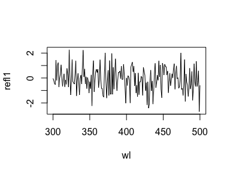

```r
plot(refl1 ~ wl, type = "l", data = fakedat.new2)
```

We want to stress that it is important to check the actual wavelengths contained in the data before setting this argument (`as.rspec()` will warn you when wavelengths in the data are not present in the range specified with `lim`), otherwise `as.rspec()` will assume that wavelengths exist when in fact they may not. For example, if we set `lim = c(300, 1000)` and plot the results, the reflectance values between 700 and 1000 nm are set to be equal since there is no information at these wavelengths in the original dataset:

```r
fakedat.new2 <- as.rspec(fakedat, lim = c(300, 1000))
```

```
## wavelengths found in column 3
```

```
## Warning in as.rspec(fakedat, lim = c(300, 1000)): Interpolating beyond the
## range of actual data. Check 'lim' and `exceed.range` arguments to confirm
## this is the desired behaviour.
```

```
##
## The spectral data contain 858 negative value(s), which may produce unexpected results if used in models. Consider using procspec() to correct them.
```

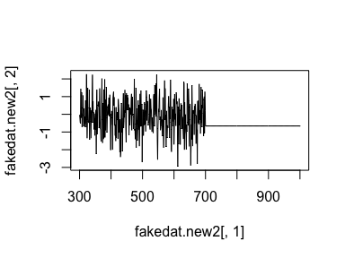

```r
plot(fakedat.new2[, 2] ~ fakedat.new2[, 1], type = "l")
```

## Subsetting and Merging Spectral Data

Once an `rspec` object has been created, either by importing raw spectral data or converting a dataset with the `as.rspec()` function, you can subset the spectra based on their names using a modified version of `R`’s built-in `subset` function. For example, the following code illustrates how to create an `rspec` object containing only tanagers:

```r
specs.tanager1 <- subset(specs, "tanager")

head(specs.tanager1)[1:5]
```

```
##    wl tanager.0001 tanager.0002 tanager.0003 tanager.0004
## 1 300      10.0618      10.6744      10.1499      13.7473
## 2 301      11.1472      10.8054       9.8003      14.3102
## 3 302      10.7819      10.6134       9.5607      14.4463
## 4 303      11.0210      11.2037      10.4107      15.5533
## 5 304      10.2177      11.2120       9.9452      14.3841
## 6 305      11.5664      11.6135      10.8659      15.6445
```

The `subset` function here is using partial matching to find all spectra with the string “tanager” in their name. To fully benefit from this flexible subsetting functionality, it is important that you follow a consistent file naming scheme. For example, `tanager.14423.belly.001.ttt` would indicate the species (tanager), individual ID (14423), body patch (belly) and measurement number (001). Additionally, we suggest that labels used should have the same number of characters, which simplifies character string manipulation and subsetting based on partial matching.

If you prefer not to use partial matching, `subset` will also work if you provide a logical condition, similar to the default `subset` behaviour in `R`. For example:

```r
# extract first component of filenames containing species names
spp <- do.call(rbind, strsplit(names(specs), "\\."))[, 1]

# subset
specs.tanager2 <- subset(specs, subset = spp == "tanager")

# compare subsetting methods
all.equal(specs.tanager1, specs.tanager2)
```

```
## [1] TRUE
```

Note that `subset` will also work with visual model (class `vismodel`) and colspace (class `colspace`) objects, as described below.

Another useful function is `merge`. Let’s say that you have subsetted spectra for tanagers and parakeets, and you would like to re-combine them for an analysis. The following lines of code show how to do this:

```r
specs.tanager <- subset(specs, "tanager")
specs.parakeet <- subset(specs, "parakeet")
specs.new <- merge(specs.tanager, specs.parakeet)
```

Note that this re-combined file (`specs.new`) has only a single `wl` column with the merged spectra as columns. Keep in mind that the order of objects in `merge` will determine the order of columns in the final merged object (i.e. tanagers will be before parakeets).

# Processing Spectral Data

## Averaging Spectra

```r
# 36 spectra plus the first (wl) column
explorespec(specs[, 1:37], by = 3, lwd = 2)
```

[figure not shown]

Result from `explorespec`, showing the three measurements for each individual cardinal in separate panels

So our first step would be to take the average of each of these three measurements to obtain average individual spectra to be used in further analyses. This is easily accomplished using the `aggspec()` function. The `by` argument can be either a number (specifying how many specs should be averaged for each new sample) or a vector specifying the identities of the spectra to be combined (see below):

```r
mspecs <- aggspec(specs, by = 3, FUN = mean)
mspecs[1:5, 1:4]
```

```
##    wl cardinal cardinal.1 cardinal.2
## 1 300 7.292933   5.676700   6.387233
## 2 301 7.759200   5.806700   6.698200
## 3 302 7.959333   5.858467   6.910500
## 4 303 7.947133   6.130267   7.357567
## 5 304 8.218200   6.127933   7.195267
```

```r
dim(mspecs) # data now has 71 spectra, one for each individual, and the 'wl' column
```

```
## [1] 401  72
```

Now we’ll use the `aggspec()` function again, but this time to take the average spectrum for each species. However, each species has a different number of samples, so we can’t use the `by` argument as before. Instead we will use regular expressions to create a species name vector by removing the numbers that identify individual spectra:

```r
# create a vector with species identity names
spp <- gsub('\\.[0-9].*$', '', names(mspecs))[-1]
table(spp)
```

```
## spp
## cardinal   jacana   oriole parakeet    robin  tanager
##       12        9        9       13       10       18
```

Instead, we are going to use the `spp` vector we created to tell the `aggspec()` function how to average the spectra in `mspec`:

```r
sppspec <- aggspec(mspecs, by = spp, FUN = mean)
round(sppspec[1:5, ], 2)
```

```
##    wl cardinal jacana oriole parakeet robin tanager
## 1 300     7.05   7.33   3.89     7.63  3.98    9.02
## 2 301     7.25   7.35   3.91     7.75  3.91    9.53
## 3 302     7.44   7.45   4.13     7.89  4.19    9.41
## 4 303     7.82   8.09   4.39     8.49  4.51   10.20
## 5 304     7.84   7.71   4.18     8.66  4.07    9.68
```

## Normalizing and Smoothing Spectra

Data obtained from spectrometers often requires further processing before analysis and/or publication. For example, electrical noise can produce unwanted “spikes” in reflectance curves. The `pavo` function `procspec()` can handle a variety of processing techniques. For example, the reflectance curve from the parakeet is noisy in the short (300-400 nm) and long (650-700 nm) wavelength ranges (see Figure below, black line). To eliminate this noise, we will use local regression smoothing implemented by the `loess.smooth` function in `R`, wrapped in the `opt="smooth"` argument of `procspec()`.

But first, let’s use the `plotsmooth()` function to determine a suitable smoothing parameter (`span`). This function allows you to set a minimum and maximum smoothing parameter to try and plots the resulting curves against the unsmoothed (raw) data in a convenient multipanel figure.

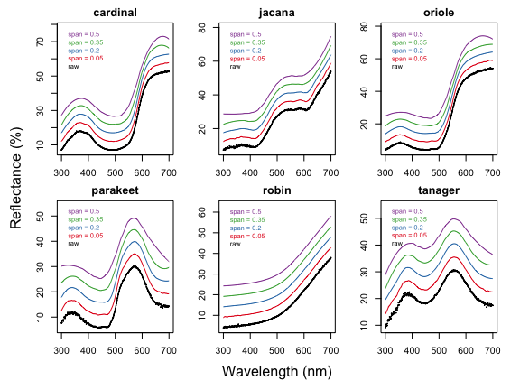

```r
plotsmooth(sppspec, minsmooth = 0.05, maxsmooth = 0.5, curves = 4, ask = FALSE)
```

From the resulting plot, we can see that `span = 0.2` is the minimum amount of smoothing to remove spectral noise while preserving the original spectral shape. Based on this value, we will now use the `opt` argument in `procspec()` to smooth data for further plotting and analysis.

```r
spec.sm <- procspec(sppspec, opt = "smooth", span = 0.2)
```

```
## processing options applied:
## smoothing spectra with a span of 0.2
```

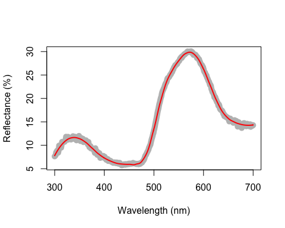

Result for raw (grey line) and smoothed (red line) reflectance data for the parakeet

```r
plot(sppspec[, 5] ~ sppspec[, 1],
  type = "l", lwd = 10, col = "grey",
  xlab = "Wavelength (nm)", ylab = "Reflectance (%)"
)
lines(spec.sm[, 5] ~ sppspec[, 1], col = "red", lwd = 2)
```

We can also try different normalisations. Options include subtracting the minimum reflectance of a spectrum at all wavelengths (effectively making the minimum reflectance equal to zero, `opt = "min"`, left panel, below) and making the reflectance at all wavelength proportional to the maximum reflectance (i.e. setting maximum reflectance to 1; `opt = "max"`, centre panel, below). Note that the user can specify multiple processing options that will be applied sequentially to the spectral data by `procspec()` (right panel, below).

```r
# Run some different normalisations
specs.max <- procspec(sppspec, opt = "max")
```

```
## processing options applied:
## Scaling spectra to a maximum value of 1
```

```r
specs.min <- procspec(sppspec, opt = "min")
```

```
## processing options applied:
## Scaling spectra to a minimum value of zero
```

```r
specs.str <- procspec(sppspec, opt = c("min", "max")) # multiple options
```

```
## processing options applied:
## Scaling spectra to a minimum value of zero
## Scaling spectra to a maximum value of 1
```

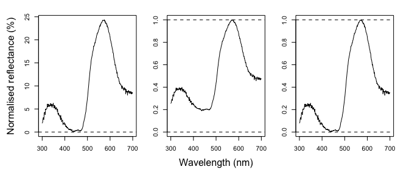

Results for min (left), max (centre), and both normalisations (right)

```r
# Plot results
par(mfrow = c(1, 3), mar = c(2, 2, 2, 2), oma = c(3, 3, 0, 0))

plot(specs.min[, 5] ~ c(300:700), xlab = "", ylab = "", type = "l")
abline(h = 0, lty = 2)

plot(specs.max[, 5] ~ c(300:700), ylim = c(0, 1), xlab = "", ylab = "", type = "l")
abline(h = c(0, 1), lty = 2)

plot(specs.str[, 5] ~ c(300:700), type = "l", xlab = "", ylab = "")
abline(h = c(0, 1), lty = 2)

mtext("Wavelength (nm)", side = 1, outer = TRUE, line = 1)
mtext("Normalised reflectance (%)", side = 2, outer = TRUE, line = 1)
```

## Binning and PCA Analysis of Spectral Shape

Another intended usage of `procspec()` is preparation of spectral data for dimensionality reduction (for example, using Principal Component Analysis, or PCA). Following [1], we can use `opt = 'center'` to centre spectra to have a mean reflectance of zero (thus removing brightness as a dominant variable in the PCA) and then bin the spectra into user-defined bins (using the `opt = 'bin'` argument) to obtain a dataframe suitable for the PCA.

```r
# PCA analysis
spec.bin <- procspec(sppspec, opt = c("bin", "center"))
```

```
## processing options applied:
## Centering spectra to a mean of zero
## binned spectra to 21-nm intervals
```

```r
head(spec.bin)
spec.bin <- t(spec.bin) # transpose so wavelength are variables for the PCA
colnames(spec.bin) <- spec.bin[1, ]  # names variables as wavelength bins
spec.bin <- spec.bin[-1, ]  # remove 'wl' column
pca1 <- prcomp(spec.bin, scale. = TRUE)
```

```r
summary(pca1)
```

```
## Importance of components:
##                           PC1    PC2    PC3     PC4     PC5       PC6
## Standard deviation     3.6041 1.9853 1.5800 0.66314 0.36427 2.705e-16
## Proportion of Variance 0.6495 0.1971 0.1248 0.02199 0.00663 0.000e+00
## Cumulative Proportion  0.6495 0.8466 0.9714 0.99337 1.00000 1.000e+00
```

As can be seen by the summary, PC1 explains approximately 64% of the variation in spectral shape and describes the ratio of short to long wavelengths reflected. The flexibility of `R` and `pavo`’s plotting capabilities allows you to sort spectra by another variable (e.g., PC1 loading) and then plot in a stacked format using the `plot` function.

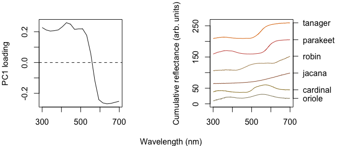

```r
# Generate colours from spectra
colr <- spec2rgb(sppspec)
wls <- as.numeric(colnames(spec.bin))

# Rank specs by PC1
sel <- rank(pca1$x[, 1])
sel <- match(names(sort(sel)), names(sppspec))

# Plot results
par(mfrow = c(1, 2), mar = c(2, 4, 2, 5), oma = c(2, 0, 0, 0))
plot(pca1$rotation[, 1] ~ wls, type = "l", ylab = "PC1 loading")
abline(h = 0, lty = 2)
plot(sppspec, select = sel, labels.stack = names(sppspec)[sel], type = "s", col = colr)
mtext("Wavelength (nm)", side = 1, outer = TRUE, line = 1)
```

## Dealing With Negative Values in Spectra

Negative values in spectra are unwanted, as they are uninterpretable (how can there be less than zero light reflected by a surface?) and can affect estimates of colour variables. Nonetheless, certain spectrometer manufacturers allow negative values to be saved. To handle negative values, the `procspec()` function has an argument called `fixneg`. The two options available are (1) adding the absolute value of the most negative value to the whole spectrum with `addmin`, and (2) changing all negative values to zero with `zero`.

```r
# Create a duplicate spectrum and add some negative values
refl <- sppspec[, 7] - 20
testspecs <- as.rspec(cbind(c(300:700), refl))
```

```
## wavelengths found in column 1
```

```
##
## The spectral data contain 188 negative value(s), which may produce unexpected results if used in models. Consider using procspec() to correct them.
```

```r
# Apply two different processing options
testspecs.fix1 <- procspec(testspecs, fixneg = "addmin")
```

```
## processing options applied:
## Negative value correction: added min to all reflectance
```

```r
testspecs.fix2 <- procspec(testspecs, fixneg = "zero")
```

```
## processing options applied:
## Negative value correction: converted negative values to zero
```

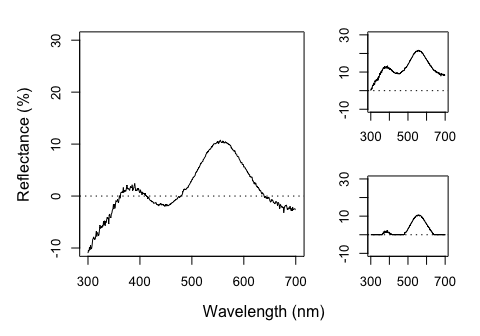

Plots showing original reflectance curve including negative values (left) and two processed curves using `fixneg = addmin` (top right) and `fixneg = zero` (bottom right).

```r
# Plot it
par(mar = c(2, 2, 2, 2), oma = c(3, 3, 0, 0))
layout(cbind(c(1, 1), c(2, 3)), widths = c(2, 1, 1))

plot(testspecs, select = 2, ylim = c(-10, 30))
abline(h = 0, lty = 3)

plot(testspecs.fix1, select = 2, ylim = c(-10, 30))
abline(h = 0, lty = 3)

plot(testspecs.fix2, select = 2, ylim = c(-10, 30))
abline(h = 0, lty = 3)

mtext("Wavelength (nm)", side = 1, outer = TRUE, line = 1)
mtext("Reflectance (%)", side = 2, outer = TRUE, line = 1)
```

These manipultions may have different effects on the final spectra, which the user should keep in mind and use according to the final goal of the analysis. For example, by adding the minimum reflectance to all other wavelength, the shape of the curve is preserved, but the maximum reflectance is much higher. On the other hand, substituting negative values with zero preserves absolute reflectance values, but may cause the spectral shape to be lost. The “best” transformation will depend on the severity of the problem of negative values and the goal of the analysis (e.g. will reflectance intensity be used? What is more important, to preserve reflectance values or the total shape of the curve?). Which correction to use would also depend on the source of the negative values. If they are thought to originate from improper calibration of the spectrophotometer, `fixneg = addmin` would be appropriate. However, if they are thought to originate from electric noise, `fixneg = zero` would be more appropriate.

# Visualizing Spectral Data

`pavo` offers three main plotting functions. The main one is `plot`, which combines several different options in a flexible framework for most commonly used purposes. The `explorespec()` function aims at providing initial exploratory analysis, as demonstrated in Section 1. Finally, `aggplot()` provides a simple framework for publication-quality plots of aggregated spectral data.

## The `plot` Function Options

Since `pavo` uses the class `rspec` to identify spectral data, the function `plot.rspec()` can be called simply by calling `plot(data)`. If the object is not of class `rspec` the multivariate visualisation methods will not work as expected, so it might be useful to check the data using `is.rspec()` and convert with `as.rspec()` if necessary.

We have implemented three methods of visualizing spectral data using `plot`:

1. **Overlay**: all spectra plotted with same x- and y-axis
2. **Stack**: spectra plotted with same x-axis but arranged vertically along y-axis
3. **Heatmap**: false colour map to illustrate three dimensional data

### The `overlay` Option

We can start out by visualizing these spectra with the `overlay` option in plot. Another neat option `pavo` offers is to convert reflectance spectra to their approximate perceived colour, by using the function `spec2rgb()`. This can make for some very interesting plots and even exploratory data analysis, as shown above.

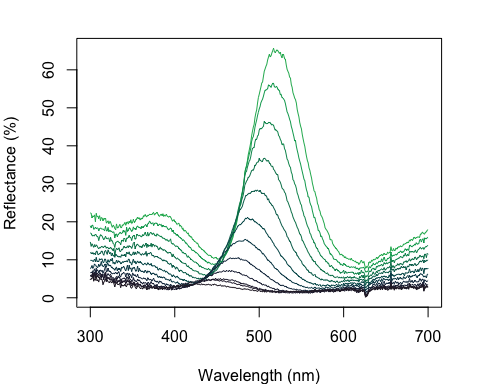

Overlay plot of the teal angle-dependent reflectance with colours of each curve being an approximation of the perceived colour.

```r
par(mar = c(4, 4, 2, 2))
data(teal)
plot(teal, type = "o", col = spec2rgb(teal))
```

### The `stack` Option

Another option is the `stack` plot (again, with human vision approximations of the colour produced by the spectra using `spec2rgb()`).

```r
teal.norm <- procspec(teal, opt = c("min", "max"))
```

```
## processing options applied:
## Scaling spectra to a minimum value of zero
## Scaling spectra to a maximum value of 1
```

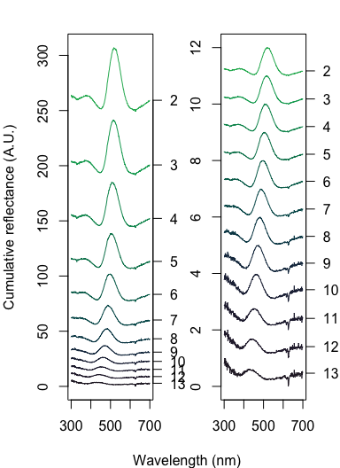

Stacked plot of the raw (left) and normalized (right) teal angle-dependent reflectance

```r
par(mfrow = c(1, 2), mar = c(2, 2, 2, 2), oma = c(2, 2, 0, 0))

plot(teal, type = "s", col = spec2rgb(teal))
plot(teal.norm, type = "s", col = spec2rgb(teal))

mtext("Wavelength (nm)", side = 1, outer = T, line = 1)
mtext("Cumulative reflectance (A.U.)", side = 2, outer = T, line = 1)
```

Note that in the above figure, the y axis to the right includes the index of each spectrum. This makes it easier to identify and subset specific spectra or groups of spectra using the `select` argument in `plot.rspec()`. Note also that the first index is actually 2, preserving the sequence in the original dataset (since the first column is wavelength). Though this may seem confusing at first (“why is my first spec number 2?”) this preserves subsetting hierarchy: using `plot(teal, select = 2)` will show the same spectra that would be selected if you use `teal[ ,2]`.

### The `heatmap` Option

Since this dataset is three-dimensional (containing wavelengths, reflectance values and incident angles) we can also use the `heatmap` function. First, it will be necessary to define a vector for the incident angles each spectrum was measured at:

```r
angles <- seq(15, 70, by = 5)
```

Next, we will smooth the data with `procspec()` and plot as a false colour map (heatmap):

```r
# Smooth the spectral data
teal.sm <- procspec(teal, opt = c("smooth"))
```

```
## processing options applied:
## smoothing spectra with a span of 0.25
```

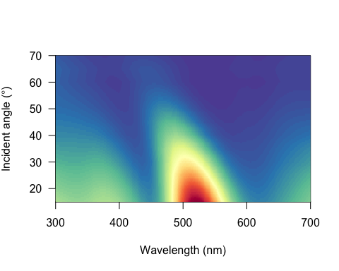

Heatmap plot for angle-resolved reflectance measurements of the green-winged teal.

```r
# Plot it as a heatmap
plot(teal.sm,
  type = "h", varying = angles,
  ylab = expression(paste("Incident angle (", degree, ")")),
  las = 1, useRaster = TRUE
)
```

These plots can be very useful to observe changes over time, for example, or any other type of continuous variation.

## The `aggplot()` Function

`aggplot()` has a very similar interface to `aggspec()`, allowing for quick plotting of aggregated spectra combined by a factor, such as species, sex, experimental treatment, and so on. Its main output is a plot with lines of group mean spectra outlined by a shaded area indicating some measure of variability, such as the standard deviation of the group. Note that functions that aren’t already implemented in R must be passed like they would be to functions such as `apply` (e.g., `function(x) sd(x)/sqrt(length(x))` in the example below).

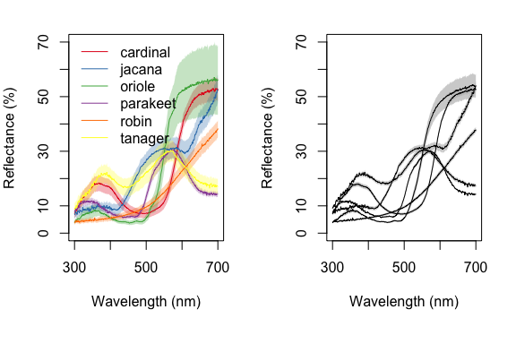

Example plots created using `aggplot`. Left: using median, standard deviation, and coloured lines. Right: using mean, standard error, and greyscale

```r
par(mfrow = c(1, 2), mar = c(4, 4, 2, 2), oma = c(2, 0, 0, 0))

# Plot using median and standard deviation, default colours
aggplot(mspecs, spp,
        FUN.center = median,
        ylim = c(0, 70),
        alpha = 0.3, legend = TRUE)

# Plot using mean and standard error, in greyscale
aggplot(mspecs, spp,
        ylim = c(0, 70),
        FUN.error = function(x) sd(x) / sqrt(length(x)),
        lcol = 1, shadecol = "grey", alpha = 0.7)
```

# Organizing Spatial (image) Data

```r
butterflies <- getimg(system.file("testdata/images/", package = 'pavo'))
```

```
## 2 files found; importing images.
```

When `pavo` imports images, it created a multidimensional object of class `rimg`, which inherits from the `array` class. If more than one image is imported, then these `rimg` objects are stored as elements in a list. All image-based functions in `pavo` are capable of working with such `rimg` lists, which allows for a more convenient and tidy high-throughput workflow. Note that while `pavo` will allow you to load, manipulate, and analyse as many images as your computer’s memory allows, it will throw a message if the total size of images in memory is greater than ca. 200mb, as this will result in noticeably slowed performance (everything will still work, it will just be slow). This may be ameliorated by reducing the size of individual images, such as through `procimg()`, or by processing images in smaller batches. All `rimg` objects have a number of identifying attributes, drawn on by image-processing functions, which can be readily inspected.

```r
is.rimg(butterflies)
```

```
## [1] TRUE
```

```r
str(butterflies[[1]])
```

```
##  'rimg' num [1:500, 1:340, 1:3] 1 1 1 1 1 1 1 1 1 1 ...
##  - attr(*, "state")= chr "raw"
##  - attr(*, "imgname")= chr "h_melpomene"
##  - attr(*, "px_scale")= logi NA
##  - attr(*, "raw_scale")= logi NA
##  - attr(*, "k")= logi NA
##  - attr(*, "outline")= logi NA
##  - attr(*, "colnames")= logi NA
##  - attr(*, "tag_loc")= logi NA
```

```r
str(butterflies[[2]])
```

```
##  'rimg' num [1:500, 1:398, 1:3] 1 1 1 1 1 1 1 1 1 1 ...
##  - attr(*, "state")= chr "raw"
##  - attr(*, "imgname")= chr "papilio"
##  - attr(*, "px_scale")= logi NA
##  - attr(*, "raw_scale")= logi NA
##  - attr(*, "k")= logi NA
##  - attr(*, "outline")= logi NA
##  - attr(*, "colnames")= logi NA
##  - attr(*, "tag_loc")= logi NA
```

If you already have images loaded into R, you can convert them to `rimg` objects using `as.rimg()`. The function will attempt to interpret a multidimensional array as an RGB image with values ranging between [0, 1], and imbue it with the custom attributes of an `rimg`. We can see this by creating a fake array, before converting it.

```r
fakeimg <- array(c(
  matrix(c(1, 1, 0, 0), nrow = 12, ncol = 8),
  matrix(c(0, 0, 0, 0), nrow = 12, ncol = 8),
  matrix(c(0, 0, 1, 1), nrow = 12, ncol = 8)),
  dim = c(12, 8, 3)
)
fake_rimg <- as.rimg(fakeimg)
is.rimg(fake_rimg)
```

```
## [1] TRUE
```

```r
str(fake_rimg)
```

```
##  'rimg' num [1:12, 1:8, 1:3] 1 1 0 0 1 1 0 0 1 1 ...
##  - attr(*, "state")= chr "raw"
##  - attr(*, "imgname")= chr "img"
##  - attr(*, "px_scale")= logi NA
##  - attr(*, "raw_scale")= logi NA
##  - attr(*, "k")= logi NA
##  - attr(*, "outline")= logi NA
##  - attr(*, "colnames")= logi NA
##  - attr(*, "tag_loc")= logi NA
```

# Visualising Image Data

## The `plot` and `summary` Functions

Thanks to the underlying class system of `pavo`, the generic functions `plot` and `summary` recognise and respond to image-data in an appropriate manner, as is the case with spectral data. A quick call to `plot`, for example, prints our images. Note that while we call an image individually below (for convenient printing in the vignette), we could simply feed the entire list of images to `plot` and it would automatically step through each image in the list upon user input.

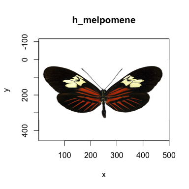

Raw images of our butterflies

```r
# Note the plot titles are taken from the file names, and can be overridden.
plot(butterflies[[1]])
```

The `summary` function offers some summary information about images or lists of images as we might expect. If we specify `plot = TRUE` however, the function instead plots the image. When such images have been colour-classified this also plots the images’ colour palette alongside (see below). This is an extremely useful diagnostic tool when classifying images, as it allows us to see how well the classification algorithm has performed in clustering colour pattern elements into discrete colour categories. As with all plots, the function takes all standard plot arguments (see `?par`), such as custom colours, which again can be diagnostically useful.

# Processing Image Data

## Overview

Images often require some post-capture processing, depending on the intended use, and `pavo` offers some useful options via `procimg()`. The functionality of `procimg()` is currently limited to only that which is closely relevant to the analyses currently implemented, as we assume any major processing and quality-checking (e.g. image rotation and colour correction) is undertaken by the user beforehand. However, should users with to keep their image processing within the R ecosystem, there now exist several excellent image-processing packages such as `imager` and `magick`, which `pavo` can seamlessly work with. Indeed, the functions `rimg2cimg()` and `cimg2rimg()` convert images from `pavo` preferred structure to that used by `imager` (and vice-versa), which simplifies the transitions between these packages.

## Setting Scales and Defining Objects

The functionality of `procimg()` is currently centred on rotating and resizing images, setting a real-world image scale, and/or distinguishing the focal object from its background. Rotating an image simply requires inputting an angle, in degrees, by which the image is rotated about its centre, while resizing requires a scaling factor by which the size of image(s) are to be decreased or increased. Setting scales and distinguishing backgrounds, in contrast, are both interactive procedures, meaning that we are presented with the focal image and must select points on it using the mouse (either a line, when setting a scale, or a polygon when identifying the focus). If setting a scale, we specify a scale in our preferred units via `scaledist`, and then click the endpoints of the scale within the image (which could be a ‘formal’ scale, or simply the length of a wing or another known reference object). This information, as usual, is attached to the image as an attribute.

```r
# Interactively specify the real-world scale of the image. Here 100 mm.
butterflies <- procimg(butterflies, scaledist = 100)
```

```r
# Interactively specify a smoothed polygon around the focal objects
butterflies <- procimg(butterflies, outline = TRUE, iterations = 1)
```

All of these options can be simultaneously specified in a single call to `procimg()`, and the `pavo 2.0` publication offers a useful example of such processing, since the more involved features are difficult illustrate to here due to their interactive nature.

# References

1. Cuthill IC, Bennett ATD, Partridge JC, Maier EJ. 1999 Plumage reflectance and the objective assessment of avian sexual dichromatism. *The American Naturalist* **153**, 183–200. (doi:10.1086/303160)